# Lista 5 - Series

#### 4. Aplique o teste aumentado de estacionariedade de Dickey-Fuller do pacote aTSA do R. Para a parte sazonal, faca a avaliacao por meio de um modelo de regressao com funcões harmonicas.

```r
# Converter a série 'Consumo_Medio_Diario' para um objeto ts
y <- ts(df$Consumo_Medio_Diario, frequency=12)
# Aplicar o teste aumentado de Dickey-Fuller
adf_result <- tseries::adf.test(y, alternative = "stationary", k =12)
```

```
##
##  Augmented Dickey-Fuller Test
##
## data:  y
## Dickey-Fuller = 0.5756, Lag order = 12, p-value = 0.99
## alternative hypothesis: stationary
```

```r
# Criar funções harmônicas para modelagem sazonal
n <- length(y)
period <- 12
t <- 1:n
harmonics <- data.frame(
  sin1 = sin(2 * pi * t / period),
  cos1 = cos(2 * pi * t / period),
  sin2 = sin(4 * pi * t / period),
  cos2 = cos(4 * pi * t / period)
)
# Adicionar uma constante às funções harmônicas
X <- cbind(1, harmonics)
# Ajustar o modelo de regressão com funções harmônicas
harmonic_model <- lm(y ~ sin1 + cos1 + sin2 + cos2, data = harmonics)
summary(harmonic_model)
```

```
##
## Call:
## lm(formula = y ~ sin1 + cos1 + sin2 + cos2, data = harmonics)
##
## Residuals:
##      Min       1Q   Median       3Q      Max
## -14.0703  -6.4166   0.6628   5.8432  10.8319
##
## Coefficients:
##              Estimate Std. Error t value Pr(>|t|)
## (Intercept) 14.327436   0.357378  40.090   <2e-16 ***
## sin1         0.007594   0.504598   0.015    0.988
## cos1         0.219941   0.506204   0.434    0.664
## sin2         0.510700   0.505395   1.010    0.313
## cos2        -0.434643   0.505371  -0.860    0.390
## ---
## Signif. codes:  0 '***' 0.001 '**' 0.01 '*' 0.05 '.' 0.1 ' ' 1
##
## Residual standard error: 6.402 on 316 degrees of freedom
## Multiple R-squared:  0.00617,    Adjusted R-squared:  -0.00641
## F-statistic: 0.4905 on 4 and 316 DF,  p-value: 0.7427
```

```r
# Extrair os resíduos do modelo
residuals <- residuals(harmonic_model)
# Aplicar o teste aumentado de Dickey-Fuller aos resíduos
adf_result_residuals <- tseries::adf.test(residuals,k = 12)
```

```
##
##  Augmented Dickey-Fuller Test
##
## data:  residuals
## Dickey-Fuller = 0.47928, Lag order = 12, p-value = 0.99
## alternative hypothesis: stationary
```

O Teste Aumentado de Dickey-Fuller (ADF) indica que a série temporal original não é estacionária, e o modelo de regressão com funções harmônicas não captura bem a sazonalidade, como demonstrado pelo baixo $R^2$ e coeficientes estatisticamente insignificantes. Além disso, o teste ADF nos resíduos do modelo mostra que eles também não são estacionários, indicando que a sazonalidade não foi removida de forma eficaz.

#### 5. Calcule a variacao do consumo $Z_t=Y_t-Y_{t-1}$, e explique o papel/significado dessa transformacao para a análise desses dados.

```r
# Calcular a diferença da série temporal
y_diff <- diff(y)
# Aplicar o teste aumentado de Dickey-Fuller à série diferenciada
adf_result_diff <- tseries::adf.test(y_diff,k=12)
print(adf_result_diff)
```

```
##
##  Augmented Dickey-Fuller Test
##
## data:  y_diff
## Dickey-Fuller = -5.1886, Lag order = 12, p-value = 0.01
## alternative hypothesis: stationary
```

A transformação para calcular a variação do consumo $Z_t=Y_t-Y_{t-1}$ é crucial para analisar séries temporais não estacionárias. A estatística ADF de -5.1886, sendo menor que todos os valores críticos, confirma que a série diferenciada é estacionária. A diferenciação foi eficaz, tornando a série adequada para modelos que assumem estacionaridade, como o ARIMA, que pode capturar tanto a parte autoregressiva quanto a média móvel.

#### 6. Faca o gráfico da evolucao temporal de $\left\{Z_t\right\}$, e descreva em um parágrafo o aspecto dessa figura, comparando-a com a forma observada no item 2.

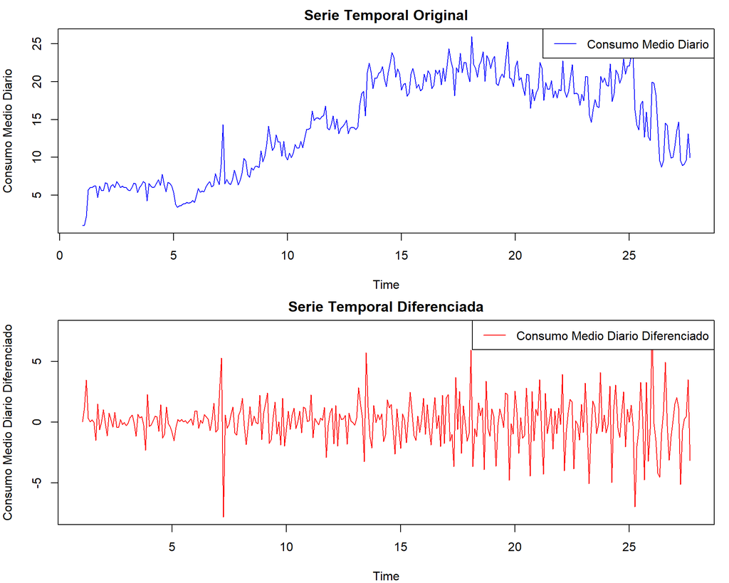